# CS 171 Final: Bering Sea Snow Crab Survey Analysis

[output not shown]

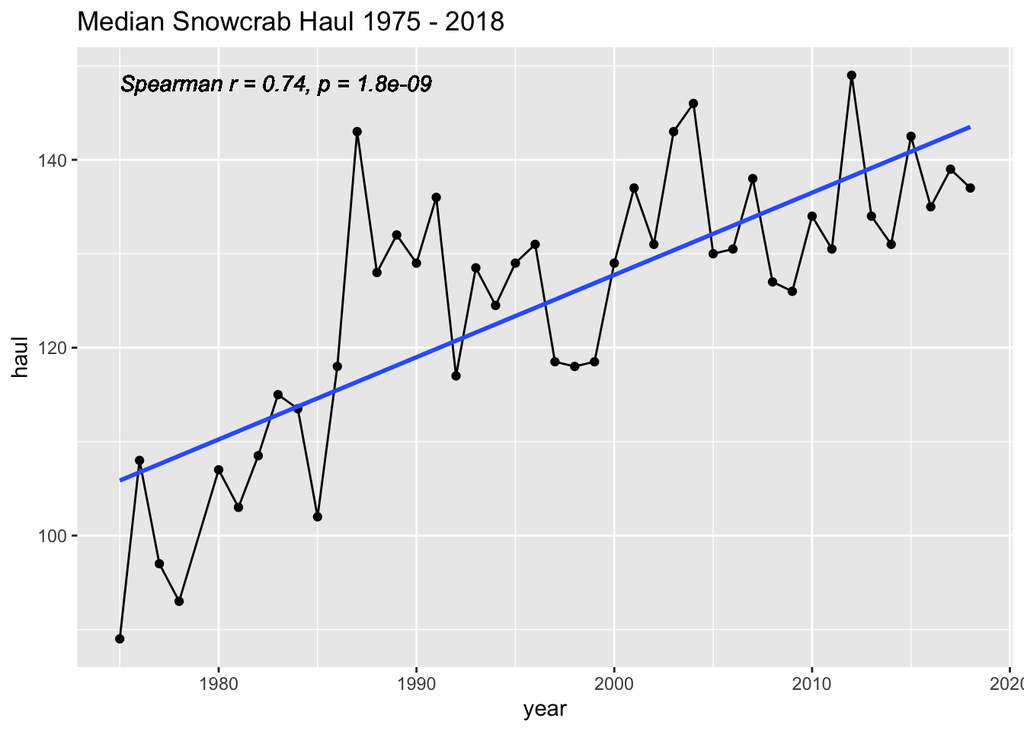

```r
p_value3 <- summary(medianmodel3)$coefficients[2, 4]

ggplot(medianKani3, aes(x = year, y = haul)) +
  geom_point() +
  geom_line() +
  stat_smooth(method = "lm", formula = y ~ x, se = FALSE) +
  labs(title = "Median Snowcrab Haul 1975 - 2018", xlab = "Years", ylab = "Median Haul") +
  geom_text(x = min(medianKani3$year), y = max(medianKani3$haul), label = paste0("Spearman r = ", round(cormedian3, 2), ", p = ", format.pval(p_value3, digits = 2)), hjust = 0, vjust = 1, fontface = "italic")
```

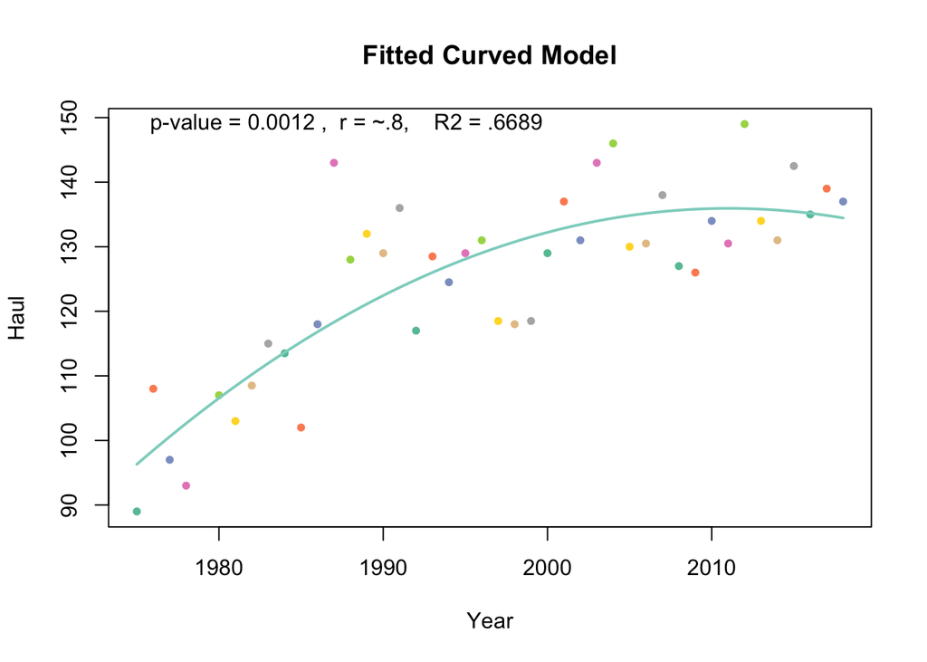

```r
#For the final chart I kept it mostly the same, however I did experiment with setting the entire color pallet to brewer set 2. What resulted is the chart which is functionally the same as the prior charts however it has a funny pastel color distribution which repeats the color palette every 8 observations.


x_seq <- seq(min(medianKani2$year), max(medianKani2$year), length.out = 100)

y_predicted <- predict(quadmodel, newdata = data.frame(year = x_seq, year2 = x_seq^2))

p_value4 <- summary(quadmodel)$coefficients[2, 4]

plot(medianKani3$year, medianKani3$haul, col = brewer.pal(n = 8, name = "Set2"), pch = 20, xlab = "Year", ylab = "Haul", main = "Fitted Curved Model")
lines(x_seq, y_predicted, col = brewer.pal(n = 8, name = "Set3"), lwd = 2)
text(x = min(medianKani3$year), y = max(medianKani3$haul), labels = paste("p-value =", round(p_value4, 4), ",  r = ~.8,    R2 = .6689"), pos = 4)
```

## Part 3: Data management!

Use the tools we learned in class to manipulate the data in an interesting manner. Please create a new column combining data in your dataset. Or subset the data, or do ANYTHING YOU LIKE! **The only condition, explain how and why you are manipulating the data** Try to answer a new question like we did in class. Execute your freedom, you can remove NAs, select only certain values, anything at all but make sure to try several tasks so you can show off your skills and I can see what you learned.

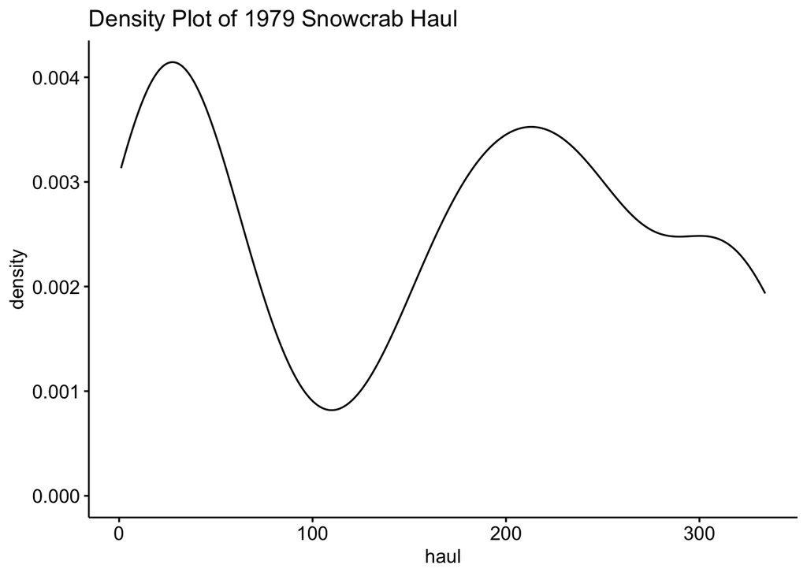

```r
# SHOW ALL OF YOUR CODE TO COMPLETE THE MISSION!!!!

#Througout the first section I had to manipulate my data, below is a copy of the text In my prior code which accomplishes this. Through these sections I chose to group my data by the year and create a new haul value based on the median of the haul data. I did this to make approaching the 18,000 observed data points more approachable for regression analysis. I used the dplyr pipe function with the group_by function. I also used the filter function to create a new tibble by removing the observed outlier observation.


medianKani <- Kani %>%
  group_by(year) %>%
  summarise(haul = median(haul))


medianKani2 <- Kani %>%
  group_by(year) %>%
  summarise(depth = median(bottom_depth))


medianKani3 <- medianKani %>%
  filter(year != 1979)

#An additional thing I thought would be cool was it I checked out/looked at what happened during the outlier observation that happened during 1979. To do this I subsetted the that year from the original dataframe and made a density plot. What we see is obvious bimodal distributions with a clear majority towards larger hauls. I thought this was cool as it shows a unique distribution showing how that year was specifically bountiful for about 2/3 of the distribution.

Kani1979 <- subset(Kani, year == "1979")

ggdensity(Kani1979, x = "haul", title = "Density Plot of 1979 Snowcrab Haul")
```

## Part 4: The end!

Make a dashboard! Take the data and create a dashboard. You will have to make a new file for this, so be sure to make a new markdown and submit it with your other files through laulima.

You can explain why you created your dashboard in the manner you chose below: